# COMP47670 Assignment II Autumn 2023

## Objective

The objective of this assignment is to identify good models for classifying time series data.  
The data is from an accelerometer sensor and there are samples of fatigued and non-fatigued running. The data has been segmented into strides and the segments (samples) are labelled F (fatigued) and NF (not fatigued). The data for two subjects A and B are available in the files `fatigueA.csv` and `fatigueB.csv`. This dataset is extracted from a much larger dataset described [here](https://openreview.net/pdf?id=9c0lAonDNP).  
At present, the best performing method for time-series classification is [Rocket](https://openreview.net/pdf?id=9c0lAonDNP). A rocket implementation is available in the [sktime tool kit](https://www.sktime.net/en/latest/api_reference/auto_generated/sktime.transformations.panel.rocket.Rocket.html). This sktime implementation can be used in this assignment.  
Some code to get you started in available in the notebook `RunningCore`.

```python
import pandas as pd
import numpy as np
import matplotlib.pyplot as plt

from sklearn.linear_model import SGDClassifier
from sklearn.model_selection import train_test_split
from sklearn.metrics import accuracy_score
```

```python
fatigue_df = pd.read_csv('fatigueA.csv', header = None) # sep = '\s+')
print(fatigue_df.shape)
fatigue_df.head(5)
```

```
(421, 181)
```

|  | 0 | 1 | 2 | 3 | 4 | 5 | 6 | 7 | 8 | 9 | ... | 171 | 172 | 173 | 174 | 175 | 176 | 177 | 178 | 179 | 180 |
| --- | --- | --- | --- | --- | --- | --- | --- | --- | --- | --- | --- | --- | --- | --- | --- | --- | --- | --- | --- | --- | --- |
| 0 | F | 2.72 | 2.69 | 2.75 | 2.89 | 3.07 | 3.27 | 3.48 | 3.67 | 3.82 | ... | 6.50 | 6.16 | 5.75 | 5.29 | 4.79 | 4.29 | 3.83 | 3.42 | 3.09 | 2.85 |
| 1 | F | 2.68 | 2.47 | 2.46 | 2.54 | 2.69 | 2.93 | 3.36 | 3.99 | 4.75 | ... | 2.79 | 3.88 | 5.18 | 6.29 | 6.88 | 6.80 | 6.13 | 5.11 | 4.04 | 3.20 |
| 2 | F | 5.04 | 5.69 | 6.21 | 6.52 | 6.59 | 6.47 | 6.26 | 6.06 | 5.91 | ... | 5.89 | 5.29 | 4.72 | 4.20 | 3.77 | 3.47 | 3.36 | 3.47 | 3.82 | 4.38 |
| 3 | F | 2.42 | 3.21 | 4.02 | 4.58 | 4.77 | 4.64 | 4.39 | 4.25 | 4.42 | ... | 8.60 | 8.76 | 8.76 | 8.32 | 7.34 | 5.91 | 4.33 | 2.97 | 2.14 | 1.98 |
| 4 | F | 3.35 | 3.40 | 3.89 | 4.71 | 5.66 | 6.47 | 6.90 | 6.81 | 6.25 | ... | 9.45 | 8.52 | 7.75 | 7.14 | 6.63 | 6.15 | 5.60 | 4.96 | 4.28 | 3.69 |

5 rows × 181 columns

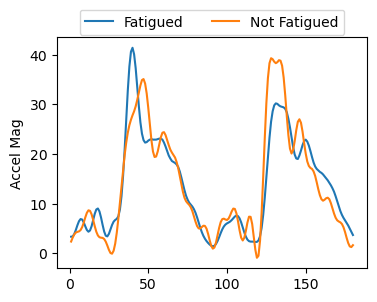

```python
fatigue_df.iloc[4][1:].plot(label='Fatigued')
fatigue_df.iloc[-5][1:].plot(figsize=(4,3), label = 'Not Fatigued')
plt.legend(loc='upper center', bbox_to_anchor=(0.5, 1.15),ncol=2)
plt.ylabel('Accel Mag')
```

### Task 1

Calculate the accuracy of a logistic regression classifier (`SGDClassifier`) on the raw time series data for subject A.

```python
# Data Preparation
y = fatigue_df.pop(0).values
X = fatigue_df.values

X_train, X_test, y_train, y_test = train_test_split(X, y, test_size=0.2, random_state=42)

# Initialize and train the SGDClassifier for logistic regression
sgd_classifier = SGDClassifier(max_iter=1000, random_state=42)
sgd_classifier.fit(X_train, y_train)

# Make predictions
y_pred = sgd_classifier.predict(X_test)

# Evaluate accuracy
accuracy = accuracy_score(y_test, y_pred)
print(f'Baseline Accuracy LR: {accuracy * 100:.2f}%')
```

```
Baseline Accuracy LR: 88.24%
```

```python
X.shape, y.shape
```

```
((421, 180), (421,))
```

- Logistic Regression with SGDClassifier Method :
> - This method is used because, of its ease of use and effectiveness in binary classification particularly when dealing with big datasets.
> - This approach be adjusted to continuous data streams because it makes use of stochastic gradient descent, which facilitates online learning.
- This above method prepares the data, divides it into training and testing sets, uses stochastic gradient descent to train a Logistic Regression model, makes predictions, assesses the accuracy, and provides a baseline performance indicator for the model is 88.24%.

### Task 2

The RunningCore Notebook contains code to convert the data to the `sktime` time-series format. Using this format assess the accuracy of the Rocket transformer coupled with an `SGDClassifier` classifier on the data for subject A.

```python
X3d = X[:,np.newaxis,:]
X3d.shape
```

```
(421, 1, 180)
```

```python
from sktime.transformations.panel.rocket import Rocket
import numpy as np
import pandas as pd
from sklearn.model_selection import train_test_split
from sktime.transformations.panel.rocket import Rocket
from sklearn.linear_model import SGDClassifier
from sklearn.pipeline import Pipeline
from sklearn.preprocessing import StandardScaler
from sklearn.metrics import accuracy_score

X_train, X_test, y_train, y_test = train_test_split(X3d, y, test_size=0.2, random_state=42)

rocket_pipeline = Pipeline([
    ('rocket', Rocket(random_state=42)),     # By Default num_kernels=10,000
    ('scaler', StandardScaler()),
    ('classifier', SGDClassifier(random_state=42))
])

rocket_pipeline.fit(X_train, y_train)
y_pred = rocket_pipeline.predict(X_test)

accuracy = accuracy_score(y_test, y_pred)
print(f'Rocket Transformer + SGDClassifier Accuracy: {accuracy * 100:.2f}%')
```

```
Rocket Transformer + SGDClassifier Accuracy: 96.47%
```

- Pipeline: Sets up the process.
- Rocket Transformation: Extracts time series data features quickly.
- Standard Scaler: Guarantees equal feature scales.
- SGD Classifier: A linear classifier designed for predictive purposes.
- Accuracy: Calculates accuracy by using a test set to assess model performance. This method of training and evaluating a time series classification model with the Rocket transformation is clear and organized.

Here, I got an accuracy by using Rocket Transformer + SGDClassifier which turns into 96.47%; that is comparatively higher than the baseline SGD accuracy 88.24%.

### Task 3

Evaluate alternatives to see if you can improve the accuracy on the raw data (Task 1). For this, you should consider alternative classifiers and data normalisation. The data should not be transformed beyond normalisation.

```python
import numpy as np
from sklearn.ensemble import RandomForestClassifier
from sklearn.model_selection import train_test_split
from sklearn.metrics import accuracy_score
from sklearn.preprocessing import MinMaxScaler, StandardScaler
from sklearn.svm import SVC
from sklearn.neighbors import KNeighborsClassifier
from sklearn.linear_model import SGDClassifier
from sklearn.model_selection import GridSearchCV
from prettytable import PrettyTable


X_train_reshaped = X_train.reshape(X_train.shape[0], -1)
X_test_reshaped = X_test.reshape(X_test.shape[0], -1)

table = PrettyTable()
table.field_names = ["Classifier", "Configuration", "Accuracy(%)"]

# classifiers with raw data
print("Before Normalisation (Subject A)\n")
classifiers_before = {
    'Random Forest': RandomForestClassifier(n_estimators=100, random_state=42),
    'SVM': SVC(random_state=42),
    'k-NN': KNeighborsClassifier(),
    'SGD Classifier': SGDClassifier(random_state=42)
}

for clf_name, clf in classifiers_before.items():
    clf.fit(X_train_reshaped, y_train)
    accuracy = accuracy_score(y_test, clf.predict(X_test_reshaped))
    table.add_row([clf_name, "Raw Data", f'{accuracy * 100:.2f}%'])

print(table)
table.clear_rows()

# classifiers with Min-Max normalized data
print("\nAfter Min-Max Normalisation (Subject A)\n")
classifiers_min_max = {
    'Random Forest': RandomForestClassifier(n_estimators=100, random_state=42),
    'SVM': SVC(random_state=42),
    'k-NN': KNeighborsClassifier(),
    'SGD Classifier': SGDClassifier(random_state=42, alpha=0.001)
}

min_max_scaler = MinMaxScaler()

for clf_name, clf in classifiers_min_max.items():
    X_train_min_max = min_max_scaler.fit_transform(X_train_reshaped)
    X_test_min_max = min_max_scaler.transform(X_test_reshaped)
    clf.fit(X_train_min_max, y_train)
    accuracy = accuracy_score(y_test, clf.predict(X_test_min_max))
    table.add_row([clf_name, "Min-Max Normalized", f'{accuracy * 100:.2f}%'])

print(table)
table.clear_rows()

# classifiers with Standard normalized data
print("\nAfter Standard Normalisation (Subject A)\n")
classifiers_standard = {
    'Random Forest': RandomForestClassifier(n_estimators=100, random_state=42),
    'SVM': SVC(random_state=42),
    'k-NN': KNeighborsClassifier(),
    'SGD Classifier': SGDClassifier(random_state=42, alpha=0.001)
}

standard_scaler = StandardScaler()

for clf_name, clf in classifiers_standard.items():
    X_train_standard = standard_scaler.fit_transform(X_train_reshaped)
    X_test_standard = standard_scaler.transform(X_test_reshaped)
    clf.fit(X_train_standard, y_train)
    accuracy = accuracy_score(y_test, clf.predict(X_test_standard))
    table.add_row([clf_name, "Standard Normalized", f'{accuracy * 100:.2f}%'])

print(table)
table.clear_rows()

# Optimizing hyperparameters for Random Forest with GridSearchCV
print("\nRandom Forest Hyperparameter tuning with GridSearchCV (Subject A) \n")
param_grid = {'n_estimators': [50, 100, 200], 'max_depth': [None, 10, 20]}
grid_search = GridSearchCV(RandomForestClassifier(random_state=42), param_grid, cv=5)
grid_search.fit(X_train_reshaped, y_train)
best_rf_classifier = grid_search.best_estimator_
best_rf_accuracy = accuracy_score(y_test, best_rf_classifier.predict(X_test_reshaped))
table.add_row(["Best - Random Forest", "Hyperparameter Tuning", f'{best_rf_accuracy * 100:.2f}%'])

print(table)
```

```
Before Normalisation (Subject A)

+----------------+---------------+-------------+
|   Classifier   | Configuration | Accuracy(%) |
+----------------+---------------+-------------+
| Random Forest  |    Raw Data   |    94.12%   |
|      SVM       |    Raw Data   |    85.88%   |
|      k-NN      |    Raw Data   |    89.41%   |
| SGD Classifier |    Raw Data   |    88.24%   |
+----------------+---------------+-------------+

After Min-Max Normalisation (Subject A)

+----------------+--------------------+-------------+
|   Classifier   |   Configuration    | Accuracy(%) |
+----------------+--------------------+-------------+
| Random Forest  | Min-Max Normalized |    94.12%   |
|      SVM       | Min-Max Normalized |    90.59%   |
|      k-NN      | Min-Max Normalized |    88.24%   |
| SGD Classifier | Min-Max Normalized |    85.88%   |
+----------------+--------------------+-------------+

After Standard Normalisation (Subject A)

+----------------+---------------------+-------------+
|   Classifier   |    Configuration    | Accuracy(%) |
+----------------+---------------------+-------------+
| Random Forest  | Standard Normalized |    94.12%   |
|      SVM       | Standard Normalized |    96.47%   |
|      k-NN      | Standard Normalized |    92.94%   |
| SGD Classifier | Standard Normalized |    88.24%   |
+----------------+---------------------+-------------+

Random Forest Hyperparameter tuning with GridSearchCV (Subject A)

+----------------------+-----------------------+-------------+
|      Classifier      |     Configuration     | Accuracy(%) |
+----------------------+-----------------------+-------------+
| Best - Random Forest | Hyperparameter Tuning |    94.12%   |
+----------------------+-----------------------+-------------+
```

### Task 4

Evaluate alternatives to improve accuracy using the Rocket transformer. Test the Rocket transformer with different numbers of kernels. Consider alternative models for the classifier stage. Again, only the data for subject A should be considered. What conclusions can you draw?

```python
from sktime.transformations.panel.rocket import Rocket
from sklearn.pipeline import Pipeline
from sklearn.linear_model import LogisticRegression
from sklearn.metrics import accuracy_score

# Set the kernel sizes
kernel_sizes = [100, 500, 1000, 5000, 7000, 10000]

# classifiers
classifiers = {
    "Logistic Regression": LogisticRegression(max_iter=1000, random_state=42),
    "SVM": SVC(random_state=42),
    "Random Forest": RandomForestClassifier(random_state=42),
    "SGD Classifier": SGDClassifier(alpha=0.001, random_state=42)
}

X_train, X_test, y_train, y_test = train_test_split(X3d, y, test_size=0.2, random_state=42)

# Loop - classifier
for clf_name, clf in classifiers.items():

    # table using prettytable
    table = PrettyTable()
    table.field_names = ["Kernel Size", "Accuracy (%)"]
    print(f"Results for {clf_name}:")

    # Loop - kernel size
    for kernel_size in kernel_sizes:

        # pipeline containing the classifier and Rocket transformer
        rocket_pipeline = Pipeline([
            ('rocket', Rocket(num_kernels=kernel_size, random_state=42)),
            ('classifier', clf)
        ])

        rocket_pipeline.fit(X_train, y_train)
        y_pred = rocket_pipeline.predict(X_test)
        accuracy = accuracy_score(y_test, y_pred)
        table.add_row([kernel_size, f'{accuracy * 100:.2f}%'])

    print(table)
    print("\n")
```

```
Results for Logistic Regression:
+-------------+--------------+
| Kernel Size | Accuracy (%) |
+-------------+--------------+
|     100     |    92.94%    |
|     500     |    97.65%    |
|     1000    |    97.65%    |
|     5000    |    96.47%    |
|     7000    |    96.47%    |
|    10000    |    96.47%    |
+-------------+--------------+


Results for SVM:
+-------------+--------------+
| Kernel Size | Accuracy (%) |
+-------------+--------------+
|     100     |    82.35%    |
|     500     |    90.59%    |
|     1000    |    91.76%    |
|     5000    |    90.59%    |
|     7000    |    90.59%    |
|    10000    |    90.59%    |
+-------------+--------------+


Results for Random Forest:
+-------------+--------------+
| Kernel Size | Accuracy (%) |
+-------------+--------------+
|     100     |    92.94%    |
|     500     |    95.29%    |
|     1000    |    95.29%    |
|     5000    |    96.47%    |
|     7000    |    96.47%    |
|    10000    |    95.29%    |
+-------------+--------------+


Results for SGD Classifier:
+-------------+--------------+
| Kernel Size | Accuracy (%) |
+-------------+--------------+
|     100     |    90.59%    |
|     500     |    85.88%    |
|     1000    |    70.59%    |
|     5000    |    90.59%    |
|     7000    |    84.71%    |
|    10000    |    97.65%    |
+-------------+--------------+
```

*Conclusion:*

The sensitivity of the Rocket transformer to variations in kernel size varies when used with different classifiers. While the accuracy of Random Forest and Logistic Regression is very good and constant, the accuracy of SVM and SGD Classifier varies significantly with different kernel sizes. To maximize the time series classification model's performance, the classifier and kernel size decisions are essential.

### Task 5

Test to see if the main conclusions from Tasks 3 and 4 hold up with the data for subject B. Comment on your findings.

```python
fatigueB_df = pd.read_csv('fatigueB.csv', header=None)
y_B = fatigueB_df.pop(0).values
X_B = fatigueB_df.values

# Data preparation
X_B_train, X_B_test, y_B_train, y_B_test = train_test_split(X_B, y_B, test_size=0.2, random_state=42)


# Before Normalisation
classifiers_before_B = {
    'Random Forest': RandomForestClassifier(n_estimators=100, random_state=42),
    'SVM': SVC(random_state=42),
    'k-NN': KNeighborsClassifier(),
    'SGD Classifier': SGDClassifier(random_state=42)
}

table_before_B = PrettyTable()
table_before_B.field_names = ["Classifier", "Configuration", "Accuracy(%)"]

for clf_name, clf in classifiers_before_B.items():
    clf.fit(X_B_train, y_B_train)
    accuracy = accuracy_score(y_B_test, clf.predict(X_B_test))
    table_before_B.add_row([clf_name, "Raw Data", f'{accuracy * 100:.2f}%'])

print("Before Normalisation (Subject B)\n")
print(table_before_B)
print("\n")

# After Min-Max Normalisation
classifiers_min_max_B = {
    'Random Forest': RandomForestClassifier(n_estimators=100, random_state=42),
    'SVM': SVC(random_state=42),
    'k-NN': KNeighborsClassifier(),
    'SGD Classifier': SGDClassifier(random_state=42, alpha=0.001)
}

min_max_scaler_B = MinMaxScaler()

table_min_max_B = PrettyTable()
table_min_max_B.field_names = ["Classifier", "Configuration", "Accuracy(%)"]

for clf_name, clf in classifiers_min_max_B.items():
    X_B_train_min_max = min_max_scaler_B.fit_transform(X_B_train)
    X_B_test_min_max = min_max_scaler_B.transform(X_B_test)
    clf.fit(X_B_train_min_max, y_B_train)
    accuracy = accuracy_score(y_B_test, clf.predict(X_B_test_min_max))
    table_min_max_B.add_row([clf_name, "Min-Max Normalized", f'{accuracy * 100:.2f}%'])

print("After Min-Max Normalisation (Subject B)\n")
print(table_min_max_B)
print("\n")

# After Standard Normalisation
classifiers_standard_B = {
    'Random Forest': RandomForestClassifier(n_estimators=100, random_state=42),
    'SVM': SVC(random_state=42),
    'k-NN': KNeighborsClassifier(),
    'SGD Classifier': SGDClassifier(random_state=42, alpha=0.001)
}

standard_scaler_B = StandardScaler()

table_standard_B = PrettyTable()
table_standard_B.field_names = ["Classifier", "Configuration", "Accuracy(%)"]

for clf_name, clf in classifiers_standard_B.items():
    X_B_train_standard = standard_scaler_B.fit_transform(X_B_train)
    X_B_test_standard = standard_scaler_B.transform(X_B_test)
    clf.fit(X_B_train_standard, y_B_train)
    accuracy = accuracy_score(y_B_test, clf.predict(X_B_test_standard))
    table_standard_B.add_row([clf_name, "Standard Normalized", f'{accuracy * 100:.2f}%'])

print("After Standard Normalisation (Subject B)\n")
print(table_standard_B)
print("\n")

# Random Forest Hyperparameter tuning with GridSearchCV
print("Random Forest Hyperparameter tuning with GridSearchCV (Subject B)\n")

param_grid_B = {'n_estimators': [50, 100, 200], 'max_depth': [None, 10, 20]}
grid_search_B = GridSearchCV(RandomForestClassifier(random_state=42), param_grid_B, cv=5)
grid_search_B.fit(X_B_train.reshape(X_B_train.shape[0], -1), y_B_train)
best_rf_classifier_B = grid_search_B.best_estimator_
best_rf_accuracy_B = accuracy_score(y_B_test, best_rf_classifier_B.predict(X_B_test.reshape(X_B_test.shape[0], -1)))

table_best_rf_B = PrettyTable()
table_best_rf_B.field_names = ["Classifier", "Configuration", "Accuracy(%)"]
table_best_rf_B.add_row(["Best - Random Forest", "Hyperparameter Tuning", f'{best_rf_accuracy_B * 100:.2f}%'])
print(table_best_rf_B)
```

```
Before Normalisation (Subject B)

+----------------+---------------+-------------+
|   Classifier   | Configuration | Accuracy(%) |
+----------------+---------------+-------------+
| Random Forest  |    Raw Data   |    90.20%   |
|      SVM       |    Raw Data   |    78.43%   |
|      k-NN      |    Raw Data   |    84.31%   |
| SGD Classifier |    Raw Data   |    80.39%   |
+----------------+---------------+-------------+


After Min-Max Normalisation (Subject B)

+----------------+--------------------+-------------+
|   Classifier   |   Configuration    | Accuracy(%) |
+----------------+--------------------+-------------+
| Random Forest  | Min-Max Normalized |    90.20%   |
|      SVM       | Min-Max Normalized |    86.27%   |
|      k-NN      | Min-Max Normalized |    80.39%   |
| SGD Classifier | Min-Max Normalized |    80.39%   |
+----------------+--------------------+-------------+


After Standard Normalisation (Subject B)

+----------------+---------------------+-------------+
|   Classifier   |    Configuration    | Accuracy(%) |
+----------------+---------------------+-------------+
| Random Forest  | Standard Normalized |    90.20%   |
|      SVM       | Standard Normalized |    90.20%   |
|      k-NN      | Standard Normalized |    80.39%   |
| SGD Classifier | Standard Normalized |    76.47%   |
+----------------+---------------------+-------------+


Random Forest Hyperparameter tuning with GridSearchCV (Subject B)

+----------------------+-----------------------+-------------+
|      Classifier      |     Configuration     | Accuracy(%) |
+----------------------+-----------------------+-------------+
| Best - Random Forest | Hyperparameter Tuning |    90.20%   |
+----------------------+-----------------------+-------------+
```

*Conclusion:*

A. Before Normalisation:

> Subject A: RF (94.12%), SVM (85.88%), k-NN (89.41%), SGD (88.24%). Subject B: RF (90.20%), SVM (78.43%), k-NN (84.31%), SGD (80.39%). Remark: Uniform patterns of raw data accuracy among subjects.

B. After Min-Max Normalisation:

> Subject A: RF (94.12%), SVM (90.59%), k-NN (88.24%), SGD (85.88%). Subject B: RF (90.20%), SVM (86.27%), k-NN (80.39%), SGD (80.39%). Remark: The impact of Min-Max normalization is constant. advantages of SVM; sensitive to k-NN.

D. Random Forest Hyperparameter Tuning:

> Subject A: Best at 94.12%. Subject B: Best at 90.20%. Remark: Subject B has a slightly lower tuning impact on accuracy, but it is still similar.

Summary:

The consistency of accuracy patterns for various classifiers on raw data across subjects indicates some classifiers show consistent performance across subjects. While using the Rocket transformer for time series classification, it is crucial to take into consideration both the classifier of choice and the kernel size. The trust in the approach's generalisation is increased by the consistent patterns observed among subjects.

## Summary:

This assignment is mainly focus on to build efficient models that combine conventional classifiers with innovative techniques such as the Rocket transformer to categorise time series data, especially that which comes from accelerometer sensors. Classifiers, normalization methods, kernel sizes, and various subjects are all take into consideration during this evaluation.